# Week 3 Homework

```r
  if(Technology == "RNAseq"){
    ACC <- paste("acc=", DS, sep = "")
    file <- paste("file=", DS, "_raw_counts_GRCh38.p13_NCBI.tsv.gz", sep = "")
    comp <- gsub(" ", "", gsm)
    comp <- gsub(",", "", comp)
    gsms <- paste0(comp)
    #### Set up DEG names ####
    urld <- "https://www.ncbi.nlm.nih.gov/geo/download/?format=file&type=rnaseq_counts"
    path <- paste(urld, ACC, file, sep="&");
    if(is.null(CountsFile)) CountsFile <- path
    cts <- data.table::fread(CountsFile, header=T)
    tbl <- as.matrix(cts, rownames="GeneID")
    exraw <- tbl
    #### Gene annotation from AnnotationHub (GEO GeneIDs are NCBI Entrez IDs) ####
    library(AnnotationHub)
    ah <- AnnotationHub()
    orgdbs <- query(ah, c("OrgDb", "Homo sapiens"))
    orgdb <- orgdbs[[tail(names(orgdbs), 1)]]
    annot <- suppressMessages(AnnotationDbi::select(orgdb, keys = rownames(tbl), keytype = "ENTREZID", columns = c("SYMBOL", "GENENAME")))
    annot <- annot[!duplicated(annot$ENTREZID), ]
    annot <- data.frame(GeneID = as.integer(annot$ENTREZID), Symbol = annot$SYMBOL, Description = annot$GENENAME)
    rownames(annot) <- annot$GeneID
    sml <- strsplit(gsms, split="")[[1]]
    sel <- which(sml != "X")
    sml <- sml[sel]
    tbl <- tbl[ ,sel]
    gs <- factor(sml)
    groups <- make.names(c("Ctrl", "Tx"))
    levels(gs) <- groups
    sample_info <- data.frame(Group = gs, row.names = colnames(tbl))
    keep <- rowSums( tbl >= 10 ) >= min(table(gs))
    tbl <- tbl[keep, ]
    ds <- DESeqDataSetFromMatrix(countData=tbl, colData=sample_info, design= ~Group)
    ds <- estimateSizeFactors(ds)
    exraw<-counts(ds, normalized=TRUE)
    ds <- DESeq(ds, test="Wald", sfType="poscount")
    r <- results(ds, contrast=c("Group", groups[2], groups[1]), alpha=0.05, pAdjustMethod ="fdr")
    tT <- r[order(r$padj)[1:length(r$padj)],]
    tT <- merge(as.data.frame(tT), annot, by=0, sort=F)
    tT <- subset(tT, select=c("GeneID","padj","pvalue","lfcSE","stat","log2FoldChange","baseMean","Symbol","Description"))
    #### subset ####
    ex2 <- data.table(subset(tT, select=c("GeneID", "Symbol", "Description", "log2FoldChange", "pvalue", "padj")))
    #### Adjust column names ####
    setnames(ex2, c("GeneID", "Symbol", "Description"), c("ENTREZID", "SYMBOL", "GENENAME"))
    #### Get Raw data ####
    GeneID <- as.integer(rownames(exraw))
    exraw <- as.data.table(exraw)
    #### Update column names ####
    exraw$ENTREZID <- GeneID
    #### merge FC and raw data together ####
    mer <- merge(ex2, exraw, by = "ENTREZID")
    return(mer)
  }
}

effectAnalysis <- function(summarizedExperiment, gene, metadata, colData = FALSE, additional = FALSE, assayNum){
  # Filter the summarized experiment based on metadata variable
  if(colData){

    metadata <- t(colData(summarizedExperiment)[[metadata]])
  }else{
    metadata <- t(rowData(summarizedExperiment)[[metadata]])
    metadata <- t(metadata)
  }
  #Check the type of data that metadata is
  metadataType <- is.numeric(metadata)

  if (metadataType){
  #Collect the expression data for the selected gene
  expressionData <- assay(summarizedExperiment,assayNum)
  expressionData <- as.data.frame(expressionData)
  expressionData$Gene <- rowData(summarizedExperiment)$SYMBOL
  expressionData <- expressionData[,c("Gene", setdiff(names(expressionData), "Gene"))]

  index <- match(gene, rowData(summarizedExperiment)$SYMBOL)

  expressionData <- expressionData[index,]

  if (!colData){
    metadata <- metadata[index,]
  }

  expressionData <- expressionData[,-1]

  # Check if the dimensions are the same so that they can be tested against one another.
  equal <- identical(dim(expressionData), dim(metadata))

  #Transform the objects into numerical vectors for correlation test

  expressionData <- as.numeric(expressionData)
  metadata <- as.numeric(metadata)

  #Proceed with analysis if the dimensions are the same
  if (equal){

  model <- lm(metadata ~ expressionData)
  pVal <- anova(model)$"Pr(>F)"[1]
  if (additional){
    plot(model)
    print(summary(model))
    print(anova(model))
  }
  return(pVal)
  } else{
    print("The dimensions are not similar.")
  }
  }
}

beyondLinear <- function(summarizedExperiment, gene, metadata, colData = FALSE, method, dataOnly = FALSE, assayNum){
  # Filter the summarized experiment based on metadata variable
  metadataName <- metadata
  if(colData){

    metadata <- t(colData(summarizedExperiment)[[metadata]])
  }else{
    metadata <- t(rowData(summarizedExperiment)[[metadata]])
    metadata <- t(metadata)
  }
  #Check the type of data that metadata is
  metadataType <- is.numeric(metadata)

  if (metadataType){
  #Collect the expression data for the selected gene
  expressionData <- assay(summarizedExperiment,assayNum)
  expressionData <- as.data.frame(expressionData)
  expressionData$Gene <- rowData(summarizedExperiment)$SYMBOL
  expressionData <- expressionData[,c("Gene", setdiff(names(expressionData), "Gene"))]

  index <- match(gene, rowData(summarizedExperiment)$SYMBOL)

  expressionData <- expressionData[index,]

  if (!colData){
    metadata <- metadata[index,]
  }

  expressionData <- expressionData[,-1]

  # Check if the dimensions are the same so that they can be tested against one another.
  equal <- identical(dim(expressionData), dim(metadata))

  #Transform the objects into numerical vectors for correlation test

  expressionData <- as.numeric(expressionData)
  metadata <- as.numeric(metadata)

  #Proceed with analysis if the dimensions are the same
  if (equal){

  model <- lm(metadata ~ expressionData)
  pVal <- anova(model)$"Pr(>F)"[1]
  if (dataOnly){
    return(list(expressionData = expressionData, metadata = metadata))
  }else{
  if (method == "LOESS"){
    model <- loess(metadata ~ expressionData, sp=0.5)


  }else if (method == "GAM"){
    model <- gam(metadata ~ s(expressionData), method="REML")
  }else if (method =="linear"){
    model <- lm(metadata ~ expressionData)
  }
  else{
    print(paste("Method:",method," not recognized. Try again."))
  }
  return(model)
  }} else{
    print("The dimensions are not similar.")
  }
  }
}
```

```r
RNAseq <- GEODataDownload("GSE116250", "GPL16791","0000000000000011111111111111111111111111111111111111111111111111","Only needed if the data was generated using MicroArrays","Only needed if the data was generated using MicroArrays","RNAseq")

norm.RNAseq <- normGEODataDownload("GSE116250", "GPL16791","0000000000000011111111111111111111111111111111111111111111111111","Only needed if the data was generated using MicroArrays","Only needed if the data was generated using MicroArrays","RNAseq")

library(SummarizedExperiment)
library(mgcv)
metadata <- read.csv("SraRunTable.csv")

rawExpression <- as.matrix(RNAseq[,c(7:70)])
normalExpression <- as.matrix(norm.RNAseq[,c(7:70)])

geneMetadata <- data.frame(
  SYMBOL = RNAseq[,2],
  log2FoldChange = RNAseq[,4],
  padj = RNAseq[,6]
)

metadata <- metadata[match(colnames(rawExpression), metadata$GEO_Accession..exp.), ]
geneIDs <- make.unique(as.character(RNAseq[,1]$ENTREZID))
rownames(rawExpression) <- geneIDs
rownames(normalExpression) <- geneIDs
rownames(geneMetadata) <- geneIDs
rownames(metadata) <- metadata$GEO_Accession..exp.
#Now lets combine everything above into a summarizedExperiment object

experiment <- SummarizedExperiment(assays = list(
    raw_counts = rawExpression,
    normalizedCounts = normalExpression
  ), rowData = geneMetadata, colData = metadata)
experiment
```

[output not shown]

### Question 2

```r
genes <- rowData(experiment)$SYMBOL
pValues <- numeric(length(genes))

for (gene in 1:length(genes)){

  pValues[gene] <- effectAnalysis(experiment, genes[gene], "AGE", colData = TRUE, additional = FALSE, assayNum = 1)
}
```

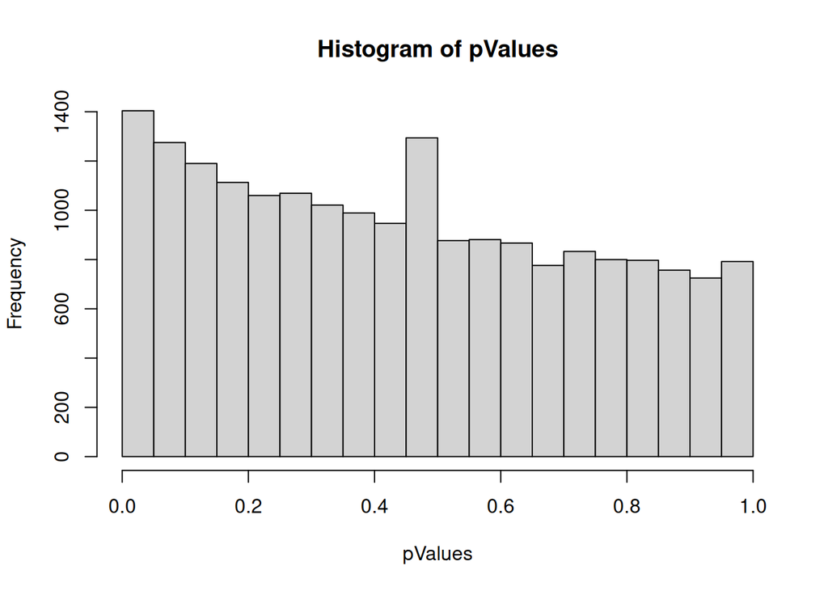

```r
hist(pValues)
```

```r
mostSig.index <- which.min(pValues)
mostSig <- genes[mostSig.index]

leastSig.index <- which.max(pValues)
leastSig <- genes[leastSig.index]
```

The gene that showed most significant relationship with age is, PRH1-TAS2R14.

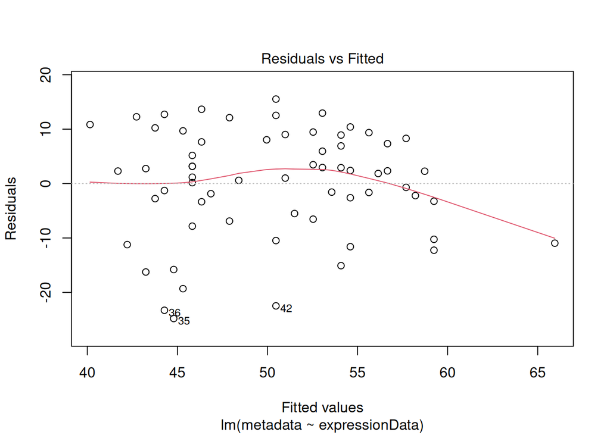

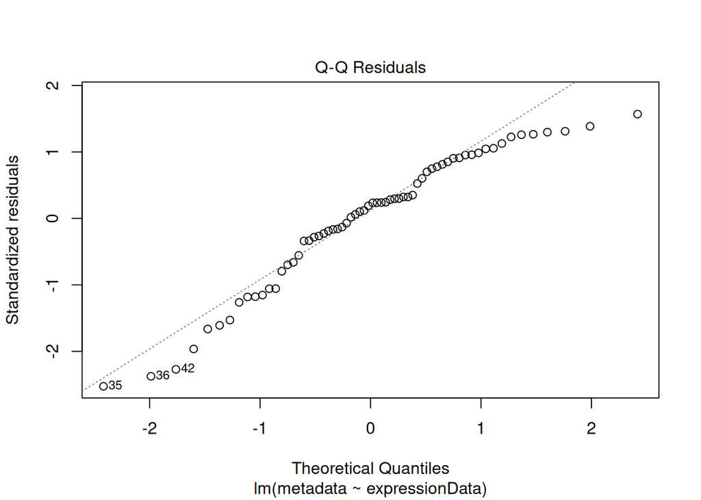

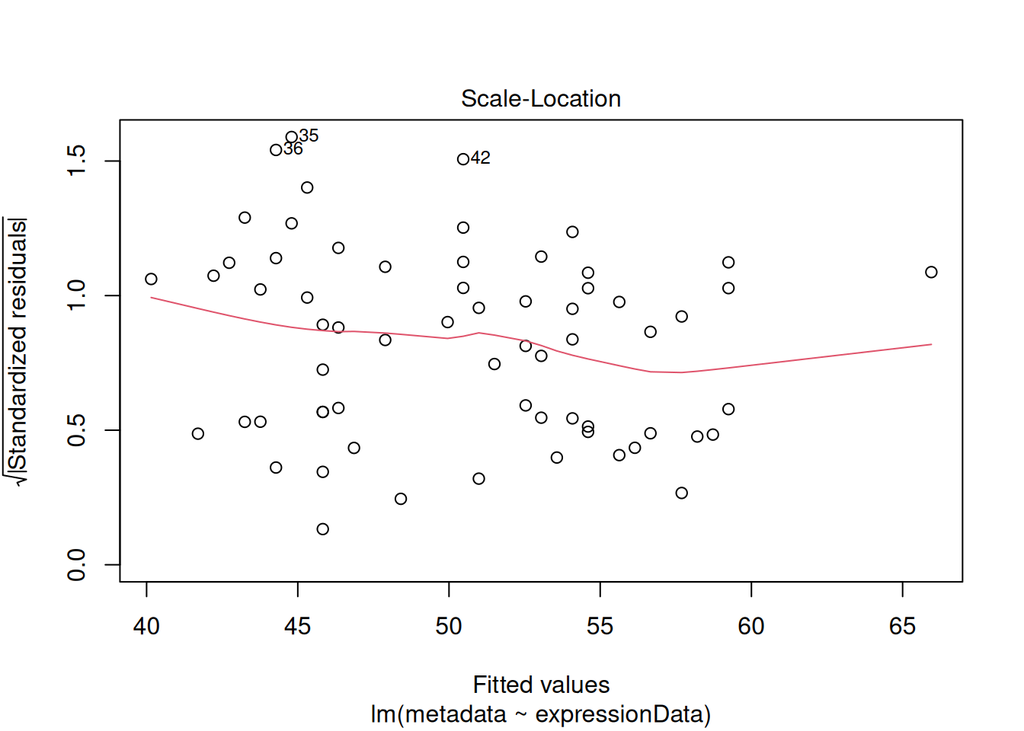

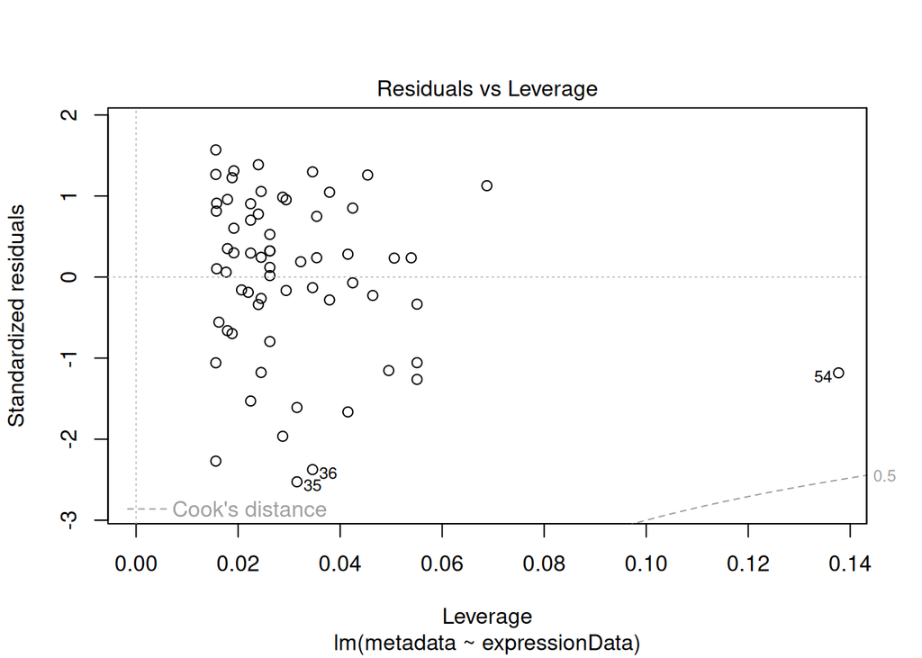

```
##
## Call:
## lm(formula = metadata ~ expressionData)
##
## Residuals:
##     Min      1Q  Median      3Q     Max
## -24.795  -5.761   2.064   8.110  15.529
##
## Coefficients:
##                Estimate Std. Error t value Pr(>|t|)
## (Intercept)     31.8956     4.3338    7.36 5.12e-10 ***
## expressionData   0.5160     0.1157    4.46 3.52e-05 ***
## ---
## Signif. codes:  0 '***' 0.001 '**' 0.01 '*' 0.05 '.' 0.1 ' ' 1
##
## Residual standard error: 9.975 on 62 degrees of freedom
## Multiple R-squared:  0.2429, Adjusted R-squared:  0.2307
## F-statistic: 19.89 on 1 and 62 DF,  p-value: 3.517e-05
##
## Analysis of Variance Table
##
## Response: metadata
##                Df Sum Sq Mean Sq F value    Pr(>F)
## expressionData  1 1978.9 1978.90   19.89 3.517e-05 ***
## Residuals      62 6168.5   99.49
## ---
## Signif. codes:  0 '***' 0.001 '**' 0.01 '*' 0.05 '.' 0.1 ' ' 1
```

```
## [1] 3.517179e-05
```

```r
effectAnalysis(experiment, mostSig,"AGE",colData = TRUE, additional = TRUE, assayNum = 1)
```

The gene that showed the least significant relationship with age is, ZNF37BP

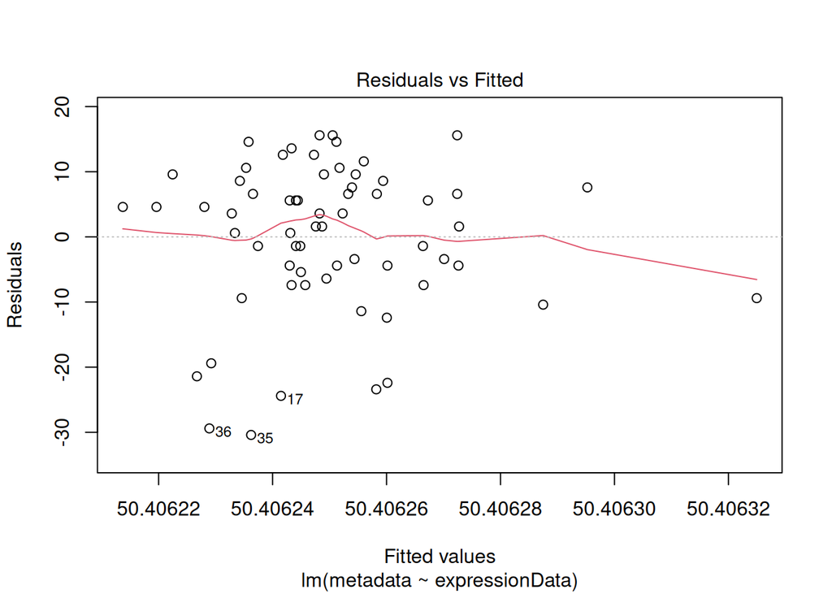

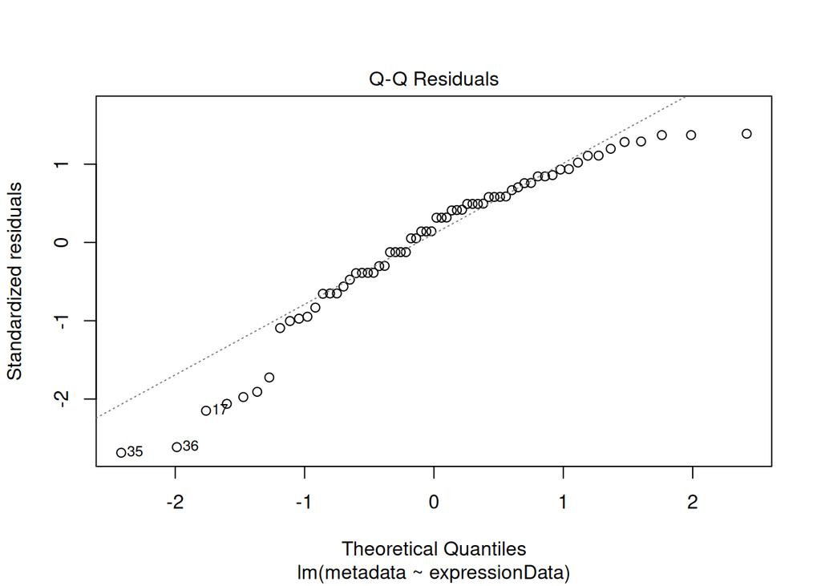

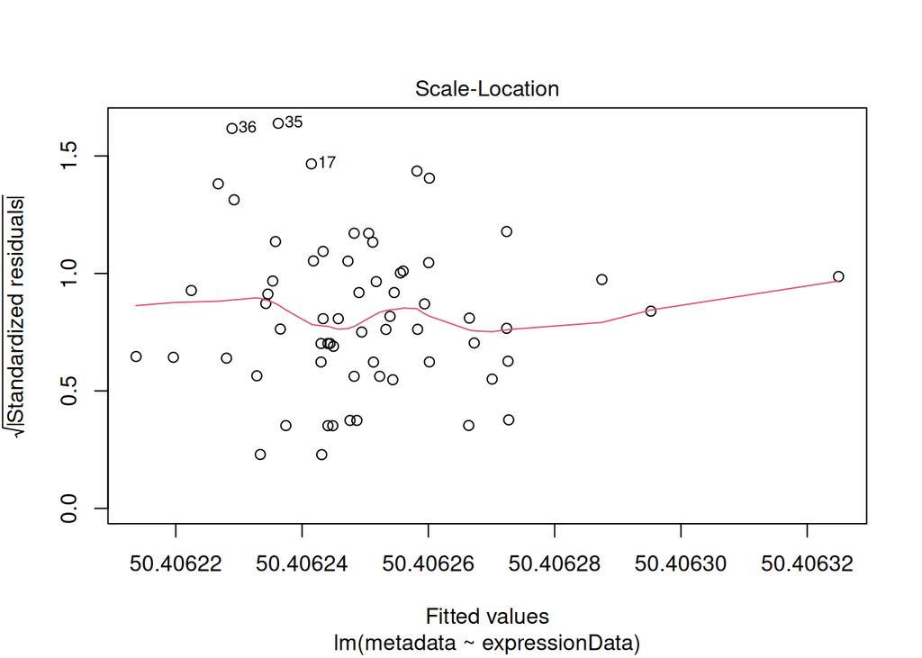

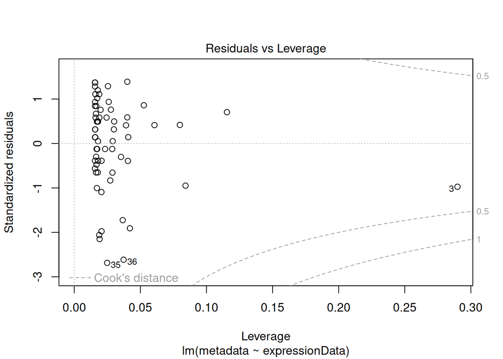

```
##
## Call:
## lm(formula = metadata ~ expressionData)
##
## Residuals:
##     Min      1Q  Median      3Q     Max
## -30.406  -5.656   2.594   7.844  15.594
##
## Coefficients:
##                 Estimate Std. Error t value Pr(>|t|)
## (Intercept)    5.041e+01  4.142e+00   12.17   <2e-16 ***
## expressionData 1.093e-07  8.752e-03    0.00        1
## ---
## Signif. codes:  0 '***' 0.001 '**' 0.01 '*' 0.05 '.' 0.1 ' ' 1
##
## Residual standard error: 11.46 on 62 degrees of freedom
## Multiple R-squared:  2.515e-12,  Adjusted R-squared:  -0.01613
## F-statistic: 1.559e-10 on 1 and 62 DF,  p-value: 1
##
## Analysis of Variance Table
##
## Response: metadata
##                Df Sum Sq Mean Sq F value Pr(>F)
## expressionData  1    0.0    0.00       0      1
## Residuals      62 8147.4  131.41
```

```
## [1] 0.9999901
```

```r
effectAnalysis(experiment, leastSig,"AGE",colData = TRUE, additional = TRUE, assayNum = 1)
```

### Question 3

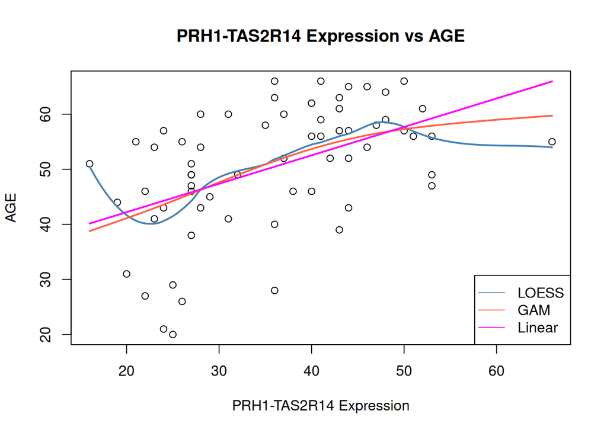

```r
geneData <- beyondLinear(experiment, mostSig, "AGE", colData = TRUE, method = "NA", dataOnly = TRUE, assayNum=1)
expressionData <- geneData$expressionData
metadata <- geneData$metadata

expData.4.pred <- seq(min(expressionData), max(expressionData), length.out=200)
newdata <- data.frame(expressionData=expData.4.pred)
LOESS.model <- beyondLinear(experiment, mostSig, "AGE", colData = TRUE, method = "LOESS", assayNum=1)
GAM.model <- beyondLinear(experiment, mostSig, "AGE", colData = TRUE, method = "GAM", assayNum=1)
linear.model <- beyondLinear(experiment, mostSig, "AGE", colData = TRUE, method = "linear", assayNum=1)

pred.LOESS <- predict(LOESS.model, newdata=newdata)
pred.GAM <- predict(GAM.model, newdata=newdata)
pred.linear <- predict(linear.model, newdata=newdata)
plot(expressionData, metadata, xlab=paste(mostSig, "Expression"), ylab="AGE", main=paste(mostSig, "Expression vs AGE"))

lines(expData.4.pred,pred.LOESS, col="steelblue", lwd=2)
lines(expData.4.pred,pred.GAM, col="tomato", lwd=2)
lines(expData.4.pred, pred.linear, col="magenta", lwd=2)
legend("bottomright",
       legend=c("LOESS","GAM","Linear"),
       col=c("steelblue","tomato","magenta"),
       pch = NA,
       lty=1)
```

Calculate AIC:

```r
lm.aic <- AIC(linear.model)
#LOESS.aic <- AIC(LOESS.model)
GAM.aic <- AIC(GAM.model)
delta.AIC <- lm.aic - GAM.aic
```

From the analysis above, we computed the AIC for the linear model (479.9975359) and the GAM model (480.1072251). The difference in these two AIC values is -0.1096892, thus we can determine the GAM plot is not any better than the linear plot as the difference is not greater than 2.

```r
resid.LOESS <- resid(LOESS.model)
resid.linear <- resid(linear.model)
resid.GAM <- resid(GAM.model)

enp.LOESS <- LOESS.model$enp
edf.GAM <- GAM.model$edf

n.LOESS <- length(resid.LOESS)
n.lm <- length(resid.linear)
n.GAM <- length(resid.GAM)


rss <- sum(resid.LOESS^2)
LOESS.aic <- n.LOESS*log(rss/n.LOESS)*(enp.LOESS+1)

aic_lm <- n.lm * log(sum(resid.linear^2) / n.lm) + 2 * (length(coef(linear.model)) + 1)
aic_gam <- n.GAM * log(sum(resid.GAM^2) / n.GAM) + 2 * (sum(edf.GAM) + 1)

delta.AIC.manual <- aic_lm - aic_gam
```

By calculating the values by hand we get the following AIC values; Linear: 298.3734037, GAM: 297.452372, LOESS: 2206.9618448. Here we see a similar relationship to above where the difference between linear and GAM models are below 2, indicating GAM is not any better than linear 0.9210317. This indicates that the linear model did not miss any relationship, and the non-linear models, GAM and LOESS, do not reveal more information regarding the relationship between PRH1-TAS2R14 and AGE.

### Question 4

Make a boxplot of the raw vs normalized data.

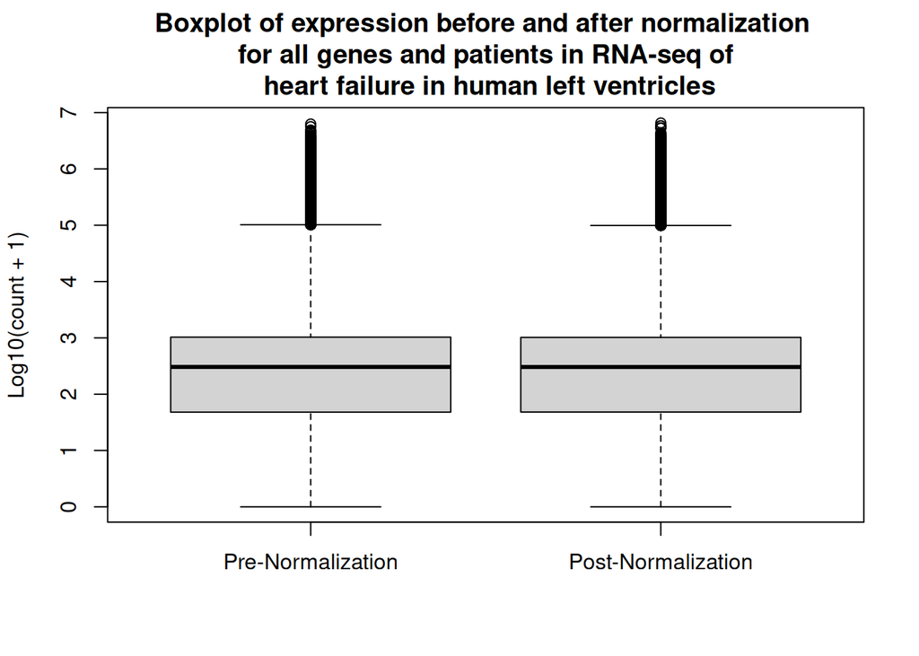

```r
rawExp <- assay(experiment,1)
#rawExp <- as.numeric(rawExp)



normExp <- assay(experiment,2)
#normExp <- as.numeric(normExp)


boxplot(list("Pre-Normalization"=as.vector(log10(as.numeric(rawExp) + 1)),"Post-Normalization"=as.vector(log10(as.numeric(normExp) + 1))),ylab="Log10(count + 1)", main = "Boxplot of expression before and after normalization \n for all genes and patients in RNA-seq of \n heart failure in human left ventricles")
```

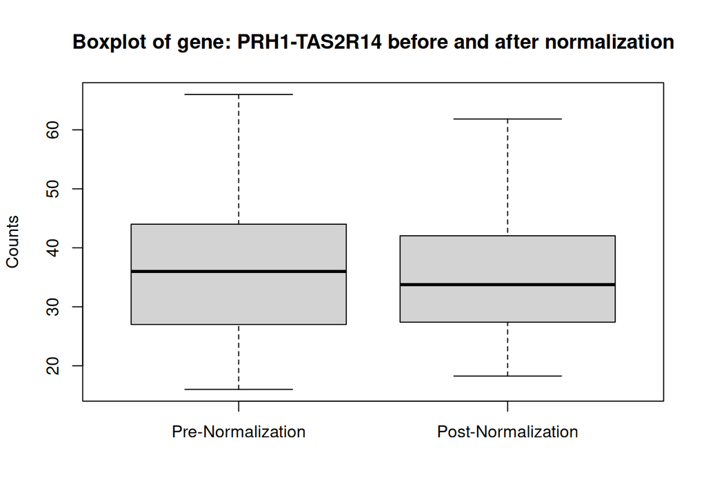

```r
#rawExp$Gene <- rowData(experiment)$SYMBOL
#rawExp <- rawExp[,c("Gene", setdiff(names(rawExp), "Gene"))]

#normExp$Gene <- rowData(experiment)$SYMBOL
#normExp <- normExp[,c("Gene", setdiff(names(normExp), "Gene"))]

rawExp.mostSig <- as.numeric(rawExp[mostSig.index,])
normExp.mostSig <- as.numeric(normExp[mostSig.index,])

boxplot(list("Pre-Normalization"=as.vector(rawExp.mostSig),"Post-Normalization"=as.vector(normExp.mostSig)), ylab="Counts", main=paste("Boxplot of gene:", mostSig, "before and after normalization"))
```

```r
pValues.norm <- numeric(length(genes))

for (gene in 1:length(genes)){

  pValues.norm[gene] <- effectAnalysis(experiment, genes[gene], "AGE", colData = TRUE, additional = FALSE, assayNum = 2)
}
```

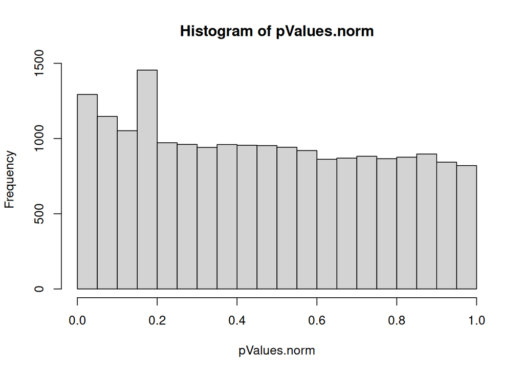

```r
hist(pValues.norm)
```

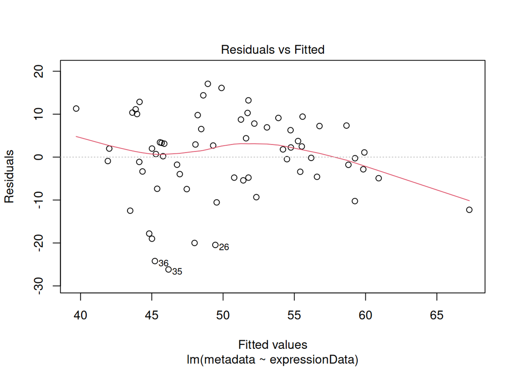

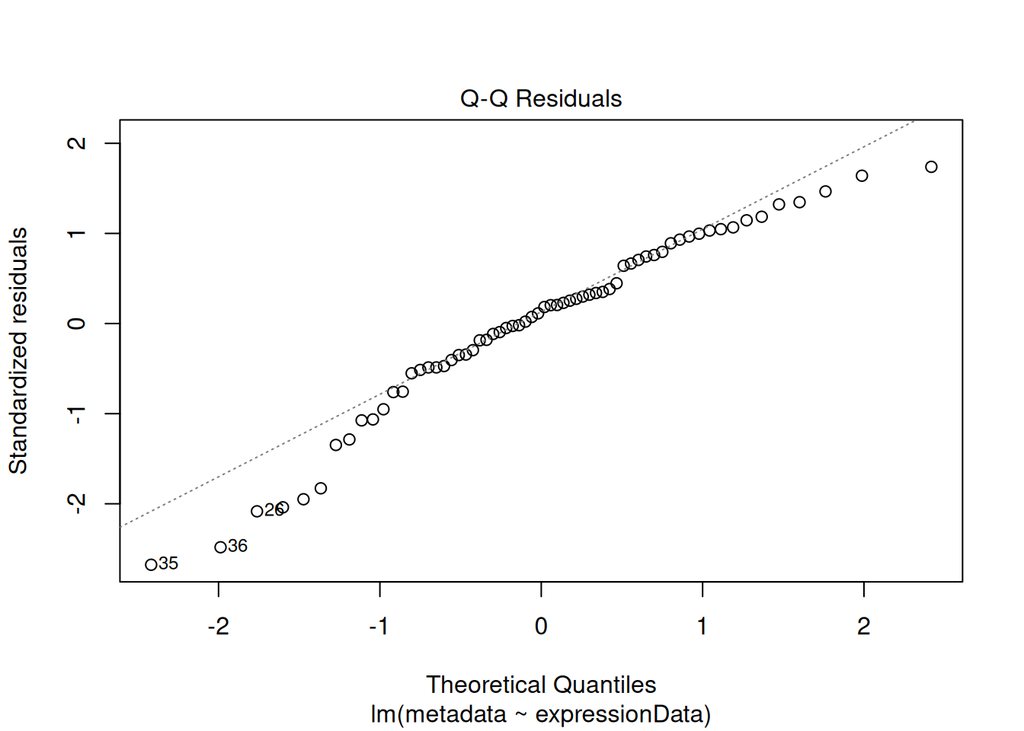

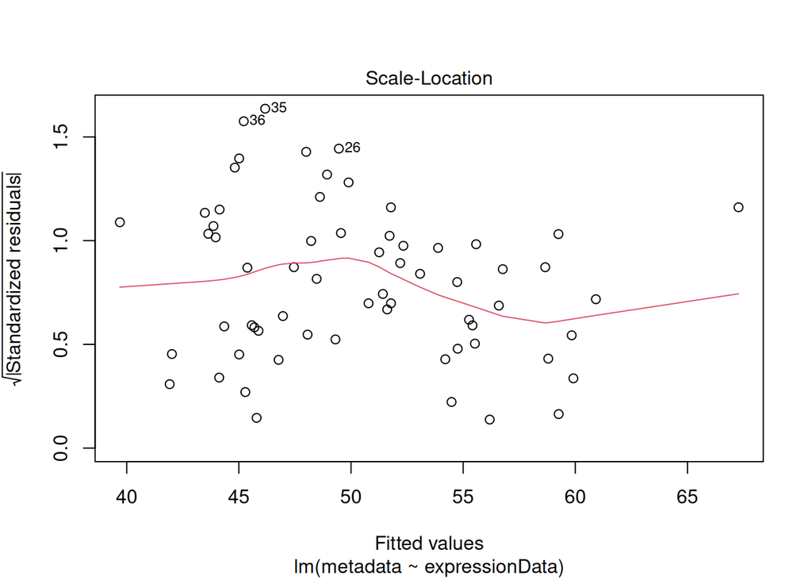

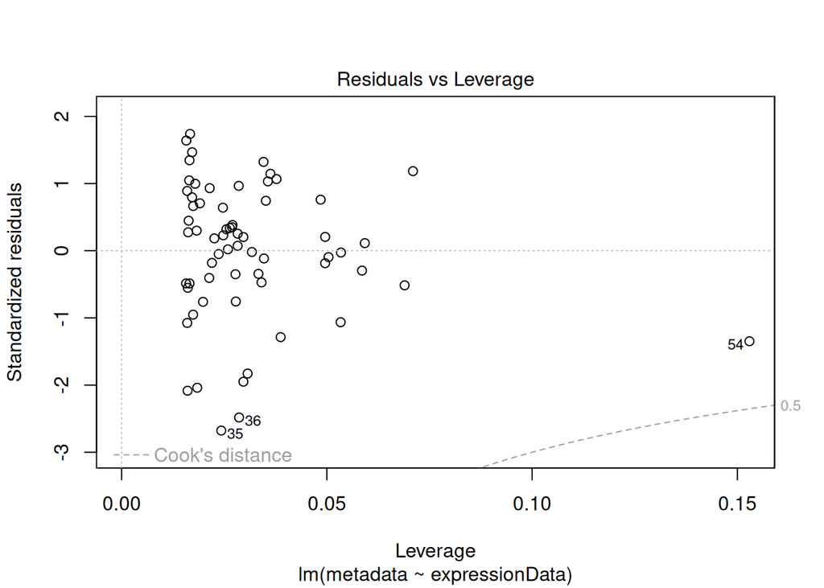

```
##
## Call:
## lm(formula = metadata ~ expressionData)
##
## Residuals:
##     Min      1Q  Median      3Q     Max
## -26.173  -4.782   1.441   7.261  17.068
##
## Coefficients:
##                Estimate Std. Error t value Pr(>|t|)
## (Intercept)     28.1380     4.9972   5.631 4.64e-07 ***
## expressionData   0.6329     0.1376   4.599 2.14e-05 ***
## ---
## Signif. codes:  0 '***' 0.001 '**' 0.01 '*' 0.05 '.' 0.1 ' ' 1
##
## Residual standard error: 9.898 on 62 degrees of freedom
## Multiple R-squared:  0.2544, Adjusted R-squared:  0.2424
## F-statistic: 21.15 on 1 and 62 DF,  p-value: 2.142e-05
##
## Analysis of Variance Table
##
## Response: metadata
##                Df Sum Sq Mean Sq F value    Pr(>F)
## expressionData  1 2072.7 2072.69  21.154 2.142e-05 ***
## Residuals      62 6074.7   97.98
## ---
## Signif. codes:  0 '***' 0.001 '**' 0.01 '*' 0.05 '.' 0.1 ' ' 1
```

```
## [1] 2.142373e-05
```

```r
effectAnalysis(experiment, mostSig,"AGE",colData = TRUE, additional = TRUE, assayNum = 2)
```

In the box-plot of pre- and post- normalized RNAseq expression counts, it is observed that the boxplots do not appear different. The mean, IQR, and outlines appear similar. However, when we plot the distribution of p-values of the normalized data, we see that the p-value distributions are shifted left compared to the initial histogram of p-value distributions. Comparing the results of models produced with raw and normalized expression data for gene PRH1-TAS2R14. It appears that the residuals vs fitted plot has a fit closer to horizontal line 0, in the raw expression model, however the model created with normalized data has a lower p-value from ANOVA.

However, in the individual boxplot of gene PRH1-TAS2R14, we can see that the variance is decreased after normalization. This reduction in variance can lead to more trustworthy results.

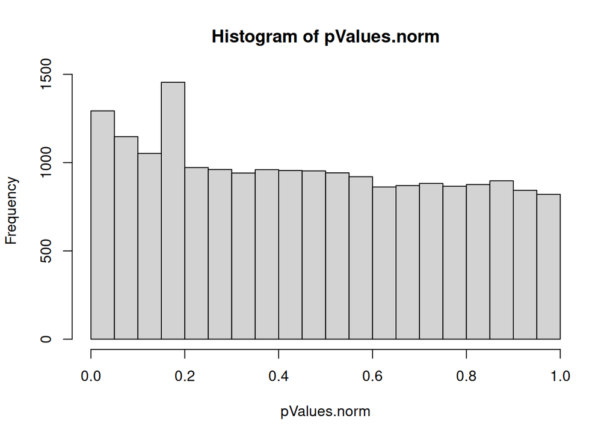

```r
hist(pValues.norm)
```

```r
mostSig.index.norm <- which.min(pValues.norm)
mostSig.norm <- genes[mostSig.index.norm]

leastSig.index.norm <- which.max(pValues.norm)
leastSig.norm <- genes[leastSig.index.norm]
```

The gene that showed most significant relationship with age, when model prepared with normalized data, is: PRH1-TAS2R14.

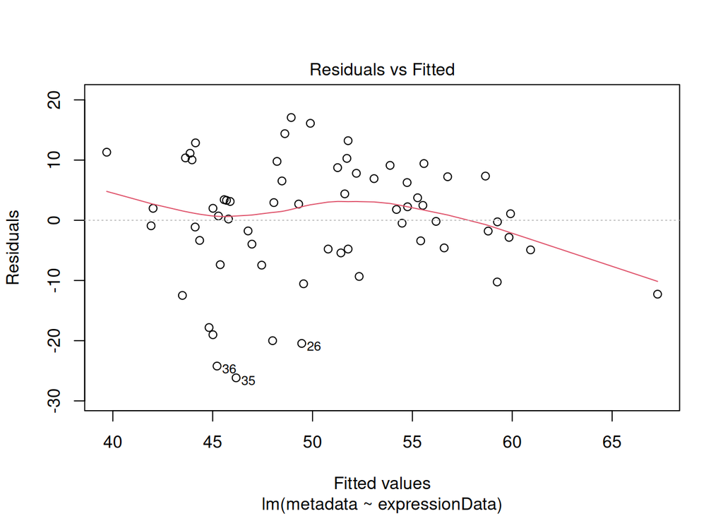

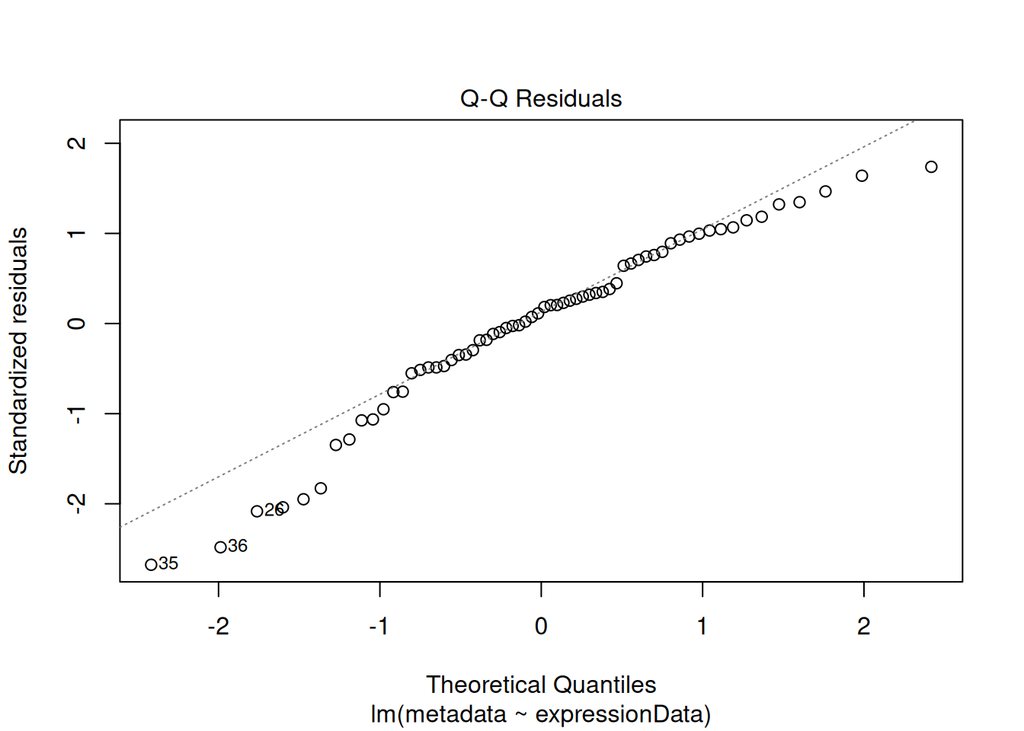

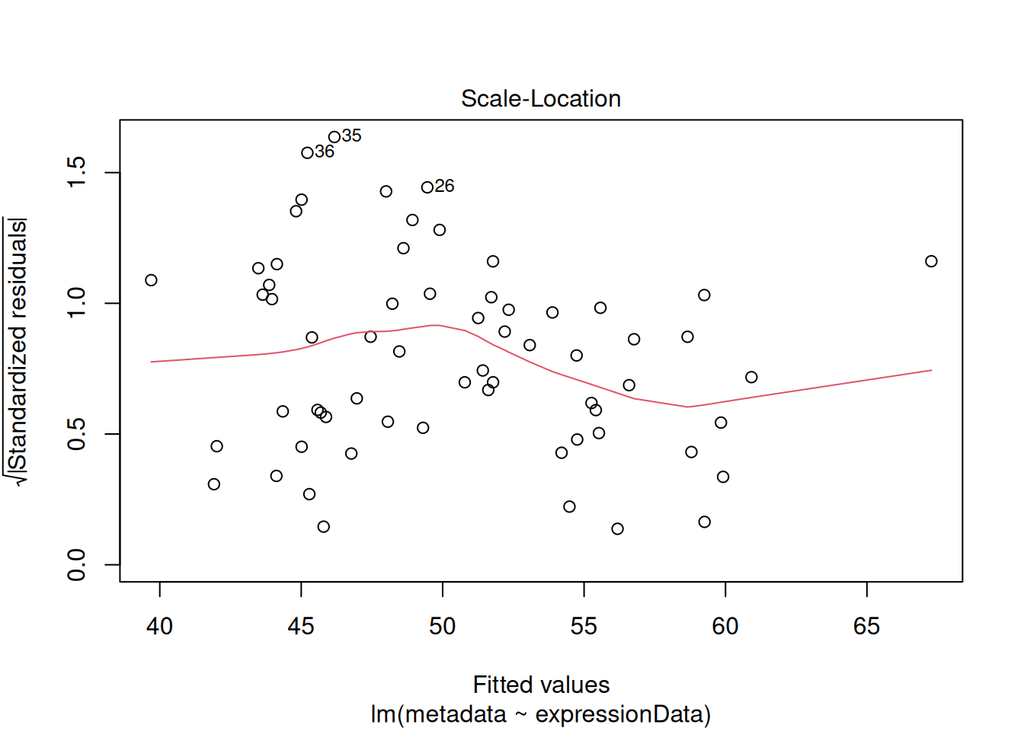

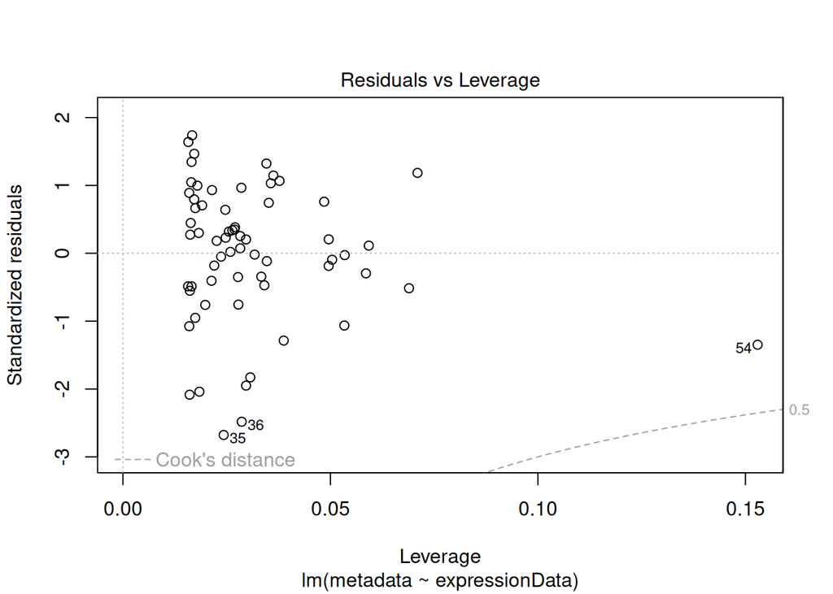

```
##
## Call:
## lm(formula = metadata ~ expressionData)
##
## Residuals:
##     Min      1Q  Median      3Q     Max
## -26.173  -4.782   1.441   7.261  17.068
##
## Coefficients:
##                Estimate Std. Error t value Pr(>|t|)
## (Intercept)     28.1380     4.9972   5.631 4.64e-07 ***
## expressionData   0.6329     0.1376   4.599 2.14e-05 ***
## ---
## Signif. codes:  0 '***' 0.001 '**' 0.01 '*' 0.05 '.' 0.1 ' ' 1
##
## Residual standard error: 9.898 on 62 degrees of freedom
## Multiple R-squared:  0.2544, Adjusted R-squared:  0.2424
## F-statistic: 21.15 on 1 and 62 DF,  p-value: 2.142e-05
##
## Analysis of Variance Table
##
## Response: metadata
##                Df Sum Sq Mean Sq F value    Pr(>F)
## expressionData  1 2072.7 2072.69  21.154 2.142e-05 ***
## Residuals      62 6074.7   97.98
## ---
## Signif. codes:  0 '***' 0.001 '**' 0.01 '*' 0.05 '.' 0.1 ' ' 1
```

```
## [1] 2.142373e-05
```

```r
effectAnalysis(experiment, mostSig.norm,"AGE",colData = TRUE, additional = TRUE, assayNum = 2)
```

The gene that showed the least significant relationship with age, when model prepared with normalized data, is: SHLD2P3

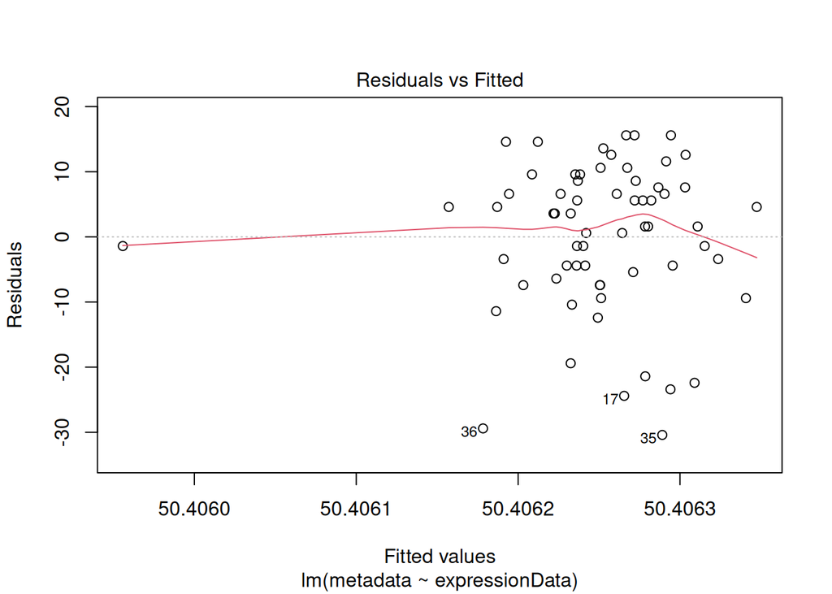

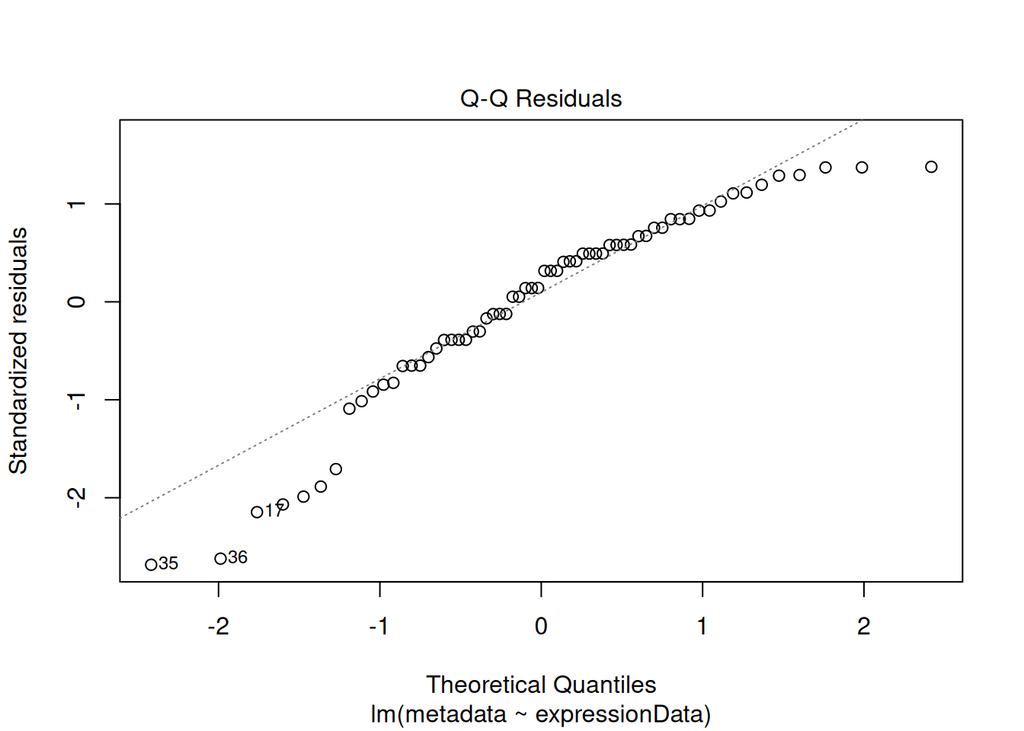

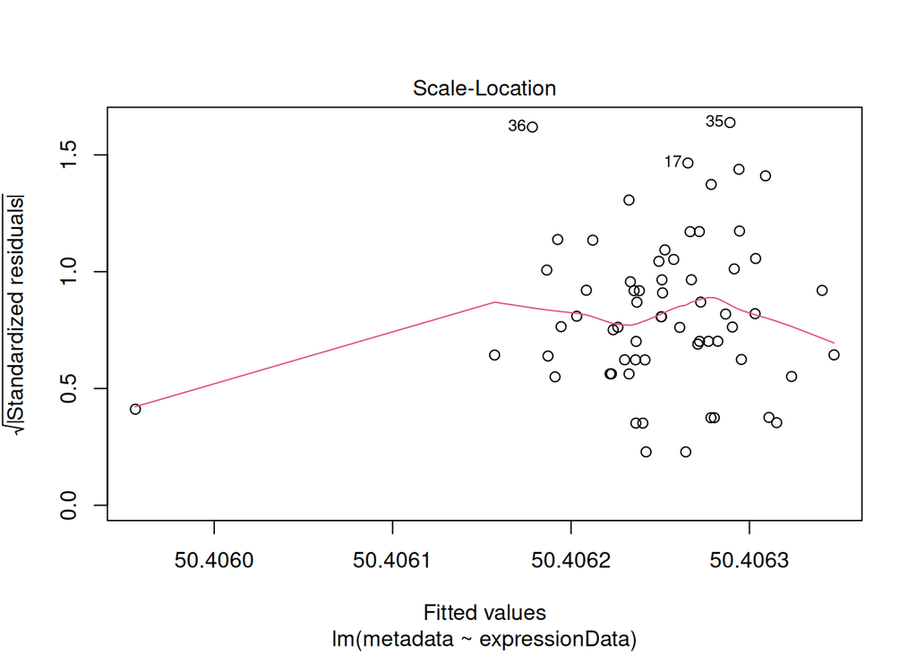

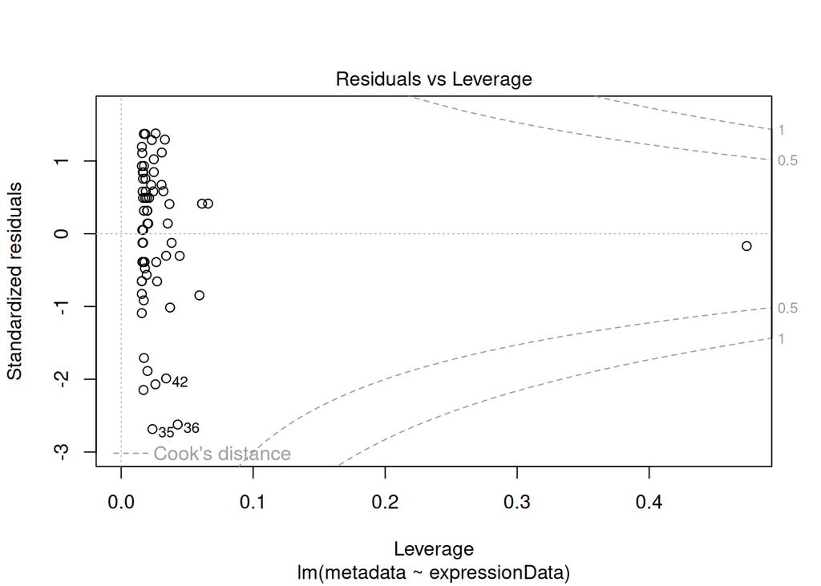

```
##
## Call:
## lm(formula = metadata ~ expressionData)
##
## Residuals:
##     Min      1Q  Median      3Q     Max
## -30.406  -5.656   2.594   7.844  15.594
##
## Coefficients:
##                  Estimate Std. Error t value Pr(>|t|)
## (Intercept)     5.041e+01  7.770e+00   6.488 1.64e-08 ***
## expressionData -9.311e-07  2.456e-02   0.000        1
## ---
## Signif. codes:  0 '***' 0.001 '**' 0.01 '*' 0.05 '.' 0.1 ' ' 1
##
## Residual standard error: 11.46 on 62 degrees of freedom
## Multiple R-squared:  2.318e-11,  Adjusted R-squared:  -0.01613
## F-statistic: 1.437e-09 on 1 and 62 DF,  p-value: 1
##
## Analysis of Variance Table
##
## Response: metadata
##                Df Sum Sq Mean Sq F value Pr(>F)
## expressionData  1    0.0    0.00       0      1
## Residuals      62 8147.4  131.41
```

```
## [1] 0.9999699
```

```r
effectAnalysis(experiment, leastSig.norm,"AGE",colData = TRUE, additional = TRUE, assayNum = 2)
```